# NLP (Natural Language Processing)

Objective: We will be building a SMS spam detector. With the input data (file containing sms data and the classification label)we have to train the model. Using this we shall build a Naive Bayes classifier model which will detect sms to be ham/spam.

# Step 1: Import Libraries

```python
import pandas as pd
import numpy as np
import random
import warnings
warnings.filterwarnings('ignore')
import seaborn as sns
import matplotlib.pyplot as plt
%matplotlib inline
```

# Step 2: Get Data

```python
df=pd.read_csv('C:\\Users\\Windows\\Desktop\\data sci\\spam.csv',encoding='latin-1')
```

# Step 3: Exploratory Data Analysis

```python
df.head()
```

|  | v1 | v2 | Unnamed: 2 | Unnamed: 3 | Unnamed: 4 |
| --- | --- | --- | --- | --- | --- |
| 0 | ham | Go until jurong point, crazy.. Available only ... | NaN | NaN | NaN |
| 1 | ham | Ok lar... Joking wif u oni... | NaN | NaN | NaN |
| 2 | spam | Free entry in 2 a wkly comp to win FA Cup fina... | NaN | NaN | NaN |
| 3 | ham | U dun say so early hor... U c already then say... | NaN | NaN | NaN |
| 4 | ham | Nah I don't think he goes to usf, he lives aro... | NaN | NaN | NaN |

```python
df=df.drop(['Unnamed: 2','Unnamed: 3','Unnamed: 4'],axis=1)
```

```python
df.describe()
```

|  | v1 | v2 |
| --- | --- | --- |
| count | 5572 | 5572 |
| unique | 2 | 5169 |
| top | ham | Sorry, I'll call later |
| freq | 4825 | 30 |

```python
df=df.rename(columns={'v1':'label','v2':'msg'})
df
```

|  | label | msg |
| --- | --- | --- |
| 0 | ham | Go until jurong point, crazy.. Available only ... |
| 1 | ham | Ok lar... Joking wif u oni... |
| 2 | spam | Free entry in 2 a wkly comp to win FA Cup fina... |
| 3 | ham | U dun say so early hor... U c already then say... |
| 4 | ham | Nah I don't think he goes to usf, he lives aro... |
| 5 | spam | FreeMsg Hey there darling it's been 3 week's n... |
| 6 | ham | Even my brother is not like to speak with me. ... |
| 7 | ham | As per your request 'Melle Melle (Oru Minnamin... |
| 8 | spam | WINNER!! As a valued network customer you have... |
| 9 | spam | Had your mobile 11 months or more? U R entitle... |
| 10 | ham | I'm gonna be home soon and i don't want to tal... |
| 11 | spam | SIX chances to win CASH! From 100 to 20,000 po... |
| 12 | spam | URGENT! You have won a 1 week FREE membership ... |
| 13 | ham | I've been searching for the right words to tha... |
| 14 | ham | I HAVE A DATE ON SUNDAY WITH WILL!! |
| 15 | spam | XXXMobileMovieClub: To use your credit, click ... |
| 16 | ham | Oh k...i'm watching here:) |
| 17 | ham | Eh u remember how 2 spell his name... Yes i di... |
| 18 | ham | Fine if thatåÕs the way u feel. ThatåÕs the wa... |
| 19 | spam | England v Macedonia - dont miss the goals/team... |
| 20 | ham | Is that seriously how you spell his name? |
| 21 | ham | IÛ÷m going to try for 2 months ha ha only joking |
| 22 | ham | So Ì_ pay first lar... Then when is da stock c... |
| 23 | ham | Aft i finish my lunch then i go str down lor. ... |
| 24 | ham | Ffffffffff. Alright no way I can meet up with ... |
| 25 | ham | Just forced myself to eat a slice. I'm really ... |
| 26 | ham | Lol your always so convincing. |
| 27 | ham | Did you catch the bus ? Are you frying an egg ... |
| 28 | ham | I'm back &amp; we're packing the car now, I'll... |
| 29 | ham | Ahhh. Work. I vaguely remember that! What does... |
| ... | ... | ... |
| 5542 | ham | Armand says get your ass over to epsilon |
| 5543 | ham | U still havent got urself a jacket ah? |
| 5544 | ham | I'm taking derek &amp; taylor to walmart, if I... |
| 5545 | ham | Hi its in durban are you still on this number |
| 5546 | ham | Ic. There are a lotta childporn cars then. |
| 5547 | spam | Had your contract mobile 11 Mnths? Latest Moto... |
| 5548 | ham | No, I was trying it all weekend ;V |
| 5549 | ham | You know, wot people wear. T shirts, jumpers, ... |
| 5550 | ham | Cool, what time you think you can get here? |
| 5551 | ham | Wen did you get so spiritual and deep. That's ... |
| 5552 | ham | Have a safe trip to Nigeria. Wish you happines... |
| 5553 | ham | Hahaha..use your brain dear |
| 5554 | ham | Well keep in mind I've only got enough gas for... |
| 5555 | ham | Yeh. Indians was nice. Tho it did kane me off ... |
| 5556 | ham | Yes i have. So that's why u texted. Pshew...mi... |
| 5557 | ham | No. I meant the calculation is the same. That ... |
| 5558 | ham | Sorry, I'll call later |
| 5559 | ham | if you aren't here in the next &lt;#&gt; hou... |
| 5560 | ham | Anything lor. Juz both of us lor. |
| 5561 | ham | Get me out of this dump heap. My mom decided t... |
| 5562 | ham | Ok lor... Sony ericsson salesman... I ask shuh... |
| 5563 | ham | Ard 6 like dat lor. |
| 5564 | ham | Why don't you wait 'til at least wednesday to ... |
| 5565 | ham | Huh y lei... |
| 5566 | spam | REMINDER FROM O2: To get 2.50 pounds free call... |
| 5567 | spam | This is the 2nd time we have tried 2 contact u... |
| 5568 | ham | Will Ì_ b going to esplanade fr home? |
| 5569 | ham | Pity, * was in mood for that. So...any other s... |
| 5570 | ham | The guy did some bitching but I acted like i'd... |
| 5571 | ham | Rofl. Its true to its name |

5572 rows × 2 columns

```python
df.label.value_counts()
```

```
ham     4825
spam     747
Name: label, dtype: int64
```

```python
df['label_num']=df.label.map({'ham':'0','spam':'1'})
df
```

|  | label | msg | label_num |
| --- | --- | --- | --- |
| 0 | ham | Go until jurong point, crazy.. Available only ... | 0 |
| 1 | ham | Ok lar... Joking wif u oni... | 0 |
| 2 | spam | Free entry in 2 a wkly comp to win FA Cup fina... | 1 |
| 3 | ham | U dun say so early hor... U c already then say... | 0 |
| 4 | ham | Nah I don't think he goes to usf, he lives aro... | 0 |
| 5 | spam | FreeMsg Hey there darling it's been 3 week's n... | 1 |
| 6 | ham | Even my brother is not like to speak with me. ... | 0 |
| 7 | ham | As per your request 'Melle Melle (Oru Minnamin... | 0 |
| 8 | spam | WINNER!! As a valued network customer you have... | 1 |
| 9 | spam | Had your mobile 11 months or more? U R entitle... | 1 |
| 10 | ham | I'm gonna be home soon and i don't want to tal... | 0 |
| 11 | spam | SIX chances to win CASH! From 100 to 20,000 po... | 1 |
| 12 | spam | URGENT! You have won a 1 week FREE membership ... | 1 |
| 13 | ham | I've been searching for the right words to tha... | 0 |
| 14 | ham | I HAVE A DATE ON SUNDAY WITH WILL!! | 0 |
| 15 | spam | XXXMobileMovieClub: To use your credit, click ... | 1 |
| 16 | ham | Oh k...i'm watching here:) | 0 |
| 17 | ham | Eh u remember how 2 spell his name... Yes i di... | 0 |
| 18 | ham | Fine if thatåÕs the way u feel. ThatåÕs the wa... | 0 |
| 19 | spam | England v Macedonia - dont miss the goals/team... | 1 |
| 20 | ham | Is that seriously how you spell his name? | 0 |
| 21 | ham | IÛ÷m going to try for 2 months ha ha only joking | 0 |
| 22 | ham | So Ì_ pay first lar... Then when is da stock c... | 0 |
| 23 | ham | Aft i finish my lunch then i go str down lor. ... | 0 |
| 24 | ham | Ffffffffff. Alright no way I can meet up with ... | 0 |
| 25 | ham | Just forced myself to eat a slice. I'm really ... | 0 |
| 26 | ham | Lol your always so convincing. | 0 |
| 27 | ham | Did you catch the bus ? Are you frying an egg ... | 0 |
| 28 | ham | I'm back &amp; we're packing the car now, I'll... | 0 |
| 29 | ham | Ahhh. Work. I vaguely remember that! What does... | 0 |
| ... | ... | ... | ... |
| 5542 | ham | Armand says get your ass over to epsilon | 0 |
| 5543 | ham | U still havent got urself a jacket ah? | 0 |
| 5544 | ham | I'm taking derek &amp; taylor to walmart, if I... | 0 |
| 5545 | ham | Hi its in durban are you still on this number | 0 |
| 5546 | ham | Ic. There are a lotta childporn cars then. | 0 |
| 5547 | spam | Had your contract mobile 11 Mnths? Latest Moto... | 1 |
| 5548 | ham | No, I was trying it all weekend ;V | 0 |
| 5549 | ham | You know, wot people wear. T shirts, jumpers, ... | 0 |
| 5550 | ham | Cool, what time you think you can get here? | 0 |
| 5551 | ham | Wen did you get so spiritual and deep. That's ... | 0 |
| 5552 | ham | Have a safe trip to Nigeria. Wish you happines... | 0 |
| 5553 | ham | Hahaha..use your brain dear | 0 |
| 5554 | ham | Well keep in mind I've only got enough gas for... | 0 |
| 5555 | ham | Yeh. Indians was nice. Tho it did kane me off ... | 0 |
| 5556 | ham | Yes i have. So that's why u texted. Pshew...mi... | 0 |
| 5557 | ham | No. I meant the calculation is the same. That ... | 0 |
| 5558 | ham | Sorry, I'll call later | 0 |
| 5559 | ham | if you aren't here in the next &lt;#&gt; hou... | 0 |
| 5560 | ham | Anything lor. Juz both of us lor. | 0 |
| 5561 | ham | Get me out of this dump heap. My mom decided t... | 0 |
| 5562 | ham | Ok lor... Sony ericsson salesman... I ask shuh... | 0 |
| 5563 | ham | Ard 6 like dat lor. | 0 |
| 5564 | ham | Why don't you wait 'til at least wednesday to ... | 0 |
| 5565 | ham | Huh y lei... | 0 |
| 5566 | spam | REMINDER FROM O2: To get 2.50 pounds free call... | 1 |
| 5567 | spam | This is the 2nd time we have tried 2 contact u... | 1 |
| 5568 | ham | Will Ì_ b going to esplanade fr home? | 0 |
| 5569 | ham | Pity, * was in mood for that. So...any other s... | 0 |
| 5570 | ham | The guy did some bitching but I acted like i'd... | 0 |
| 5571 | ham | Rofl. Its true to its name | 0 |

5572 rows × 3 columns

```python
df.describe()
```

|  | label | msg | label_num |
| --- | --- | --- | --- |
| count | 5572 | 5572 | 5572 |
| unique | 2 | 5169 | 2 |
| top | ham | Sorry, I'll call later | 0 |
| freq | 4825 | 30 | 4825 |

```python
df.info()
```

```
<class 'pandas.core.frame.DataFrame'>
RangeIndex: 5572 entries, 0 to 5571
Data columns (total 3 columns):
label        5572 non-null object
msg          5572 non-null object
label_num    5572 non-null object
dtypes: object(3)
memory usage: 65.3+ KB
```

Create a new column which will store the length of the each sms.

```python
df['length']=df['msg'].apply(len)
df
```

|  | label | msg | label_num | length |
| --- | --- | --- | --- | --- |
| 0 | ham | Go until jurong point, crazy.. Available only ... | 0 | 111 |
| 1 | ham | Ok lar... Joking wif u oni... | 0 | 29 |
| 2 | spam | Free entry in 2 a wkly comp to win FA Cup fina... | 1 | 155 |
| 3 | ham | U dun say so early hor... U c already then say... | 0 | 49 |
| 4 | ham | Nah I don't think he goes to usf, he lives aro... | 0 | 61 |
| 5 | spam | FreeMsg Hey there darling it's been 3 week's n... | 1 | 148 |
| 6 | ham | Even my brother is not like to speak with me. ... | 0 | 77 |
| 7 | ham | As per your request 'Melle Melle (Oru Minnamin... | 0 | 160 |
| 8 | spam | WINNER!! As a valued network customer you have... | 1 | 158 |
| 9 | spam | Had your mobile 11 months or more? U R entitle... | 1 | 154 |
| 10 | ham | I'm gonna be home soon and i don't want to tal... | 0 | 109 |
| 11 | spam | SIX chances to win CASH! From 100 to 20,000 po... | 1 | 136 |
| 12 | spam | URGENT! You have won a 1 week FREE membership ... | 1 | 156 |
| 13 | ham | I've been searching for the right words to tha... | 0 | 196 |
| 14 | ham | I HAVE A DATE ON SUNDAY WITH WILL!! | 0 | 35 |
| 15 | spam | XXXMobileMovieClub: To use your credit, click ... | 1 | 149 |
| 16 | ham | Oh k...i'm watching here:) | 0 | 26 |
| 17 | ham | Eh u remember how 2 spell his name... Yes i di... | 0 | 81 |
| 18 | ham | Fine if thatåÕs the way u feel. ThatåÕs the wa... | 0 | 58 |
| 19 | spam | England v Macedonia - dont miss the goals/team... | 1 | 156 |
| 20 | ham | Is that seriously how you spell his name? | 0 | 41 |
| 21 | ham | IÛ÷m going to try for 2 months ha ha only joking | 0 | 49 |
| 22 | ham | So Ì_ pay first lar... Then when is da stock c... | 0 | 53 |
| 23 | ham | Aft i finish my lunch then i go str down lor. ... | 0 | 88 |
| 24 | ham | Ffffffffff. Alright no way I can meet up with ... | 0 | 57 |
| 25 | ham | Just forced myself to eat a slice. I'm really ... | 0 | 144 |
| 26 | ham | Lol your always so convincing. | 0 | 30 |
| 27 | ham | Did you catch the bus ? Are you frying an egg ... | 0 | 134 |
| 28 | ham | I'm back &amp; we're packing the car now, I'll... | 0 | 75 |
| 29 | ham | Ahhh. Work. I vaguely remember that! What does... | 0 | 64 |
| ... | ... | ... | ... | ... |
| 5542 | ham | Armand says get your ass over to epsilon | 0 | 40 |
| 5543 | ham | U still havent got urself a jacket ah? | 0 | 38 |
| 5544 | ham | I'm taking derek &amp; taylor to walmart, if I... | 0 | 154 |
| 5545 | ham | Hi its in durban are you still on this number | 0 | 45 |
| 5546 | ham | Ic. There are a lotta childporn cars then. | 0 | 42 |
| 5547 | spam | Had your contract mobile 11 Mnths? Latest Moto... | 1 | 160 |
| 5548 | ham | No, I was trying it all weekend ;V | 0 | 34 |
| 5549 | ham | You know, wot people wear. T shirts, jumpers, ... | 0 | 87 |
| 5550 | ham | Cool, what time you think you can get here? | 0 | 43 |
| 5551 | ham | Wen did you get so spiritual and deep. That's ... | 0 | 51 |
| 5552 | ham | Have a safe trip to Nigeria. Wish you happines... | 0 | 91 |
| 5553 | ham | Hahaha..use your brain dear | 0 | 27 |
| 5554 | ham | Well keep in mind I've only got enough gas for... | 0 | 98 |
| 5555 | ham | Yeh. Indians was nice. Tho it did kane me off ... | 0 | 153 |
| 5556 | ham | Yes i have. So that's why u texted. Pshew...mi... | 0 | 63 |
| 5557 | ham | No. I meant the calculation is the same. That ... | 0 | 273 |
| 5558 | ham | Sorry, I'll call later | 0 | 22 |
| 5559 | ham | if you aren't here in the next &lt;#&gt; hou... | 0 | 66 |
| 5560 | ham | Anything lor. Juz both of us lor. | 0 | 33 |
| 5561 | ham | Get me out of this dump heap. My mom decided t... | 0 | 70 |
| 5562 | ham | Ok lor... Sony ericsson salesman... I ask shuh... | 0 | 96 |
| 5563 | ham | Ard 6 like dat lor. | 0 | 19 |
| 5564 | ham | Why don't you wait 'til at least wednesday to ... | 0 | 67 |
| 5565 | ham | Huh y lei... | 0 | 12 |
| 5566 | spam | REMINDER FROM O2: To get 2.50 pounds free call... | 1 | 147 |
| 5567 | spam | This is the 2nd time we have tried 2 contact u... | 1 | 161 |
| 5568 | ham | Will Ì_ b going to esplanade fr home? | 0 | 37 |
| 5569 | ham | Pity, * was in mood for that. So...any other s... | 0 | 57 |
| 5570 | ham | The guy did some bitching but I acted like i'd... | 0 | 125 |
| 5571 | ham | Rofl. Its true to its name | 0 | 26 |

5572 rows × 4 columns

# Step 3: Data Visualization

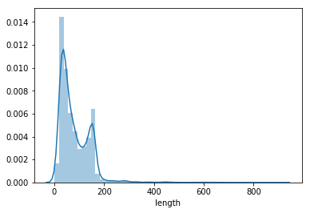

```python
import seaborn as sns
sns.distplot(df['length'])
```

```python
df['msg'].apply(len).describe()
```

```
count    5572.000000
mean       80.118808
std        59.690841
min         2.000000
25%        36.000000
50%        61.000000
75%       121.000000
max       910.000000
Name: msg, dtype: float64
```

```python
df[df['length']==910]['msg'].iloc[0]
```

```
"For me the love should start with attraction.i should feel that I need her every time around me.she should be the first thing which comes in my thoughts.I would start the day and end it with her.she should be there every time I dream.love will be then when my every breath has her name.my life shoul…
```

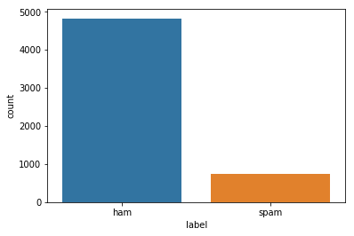

```python
sns.countplot(x='label',data=df)
```

# Step 4: Data Cleaning and Preparation (Text Preprocessing)

The text data need to be cleaned before we use the data to train the model. Let us do the below to extract significant words:

1. Remove puctuations
2. Remove stopwords

```python
from nltk.corpus import stopwords
import string
```

```python
string.punctuation
```

```
'!"#$%&\'()*+,-./:;<=>?@[\\]^_`{|}~'
```

```python
import nltk
nltk.download('stopwords')
```

```
True
```

```python
stopwords.words('english')
```

```
['i',
 'me',
 'my',
 'myself',
 'we',
 'our',
 'ours',
 'ourselves',
 'you',
 "you're",
 "you've",
 "you'll",
 "you'd",
 'your',
 'yours',
 'yourself',
 'yourselves',
 'he',
 'him',
 'his',
 'himself',
 'she',
 "she's",
 'her',
 'hers',
 'herself',
 'it',
 "it's",
 'its',
 'itself',
 'they',
 'them',
 'their',
 'theirs',
 'themselves',
 'what',
 'which',
 'who',
 'whom',
 'this',
```

[output cut: 124 more lines]

```
 "mustn't",
 'needn',
 "needn't",
 'shan',
 "shan't",
 'shouldn',
 "shouldn't",
 'wasn',
 "wasn't",
 'weren',
 "weren't",
 'won',
 "won't",
 'wouldn',
 "wouldn't"]
```

```python
nopunc=[char for char in df['msg'] if char not in string.punctuation]
nopunc
```

[output not shown]

[output cut: 946 more lines]

```
 "I'm in office now . I will call you  &lt;#&gt;  min:)",
 "Geeee ... I miss you already, you know ? Your all I can think about. Fuck, I can't wait till next year when we will be together ... *loving kiss*",
 'Yun ah.the ubi one say if Ì_ wan call by tomorrow.call 67441233 look for irene.ere only got bus8,22,65,61,66,382. Ubi cres,ubi tech park.6ph for 1st 5wkg days.Ì¬n',
 'Ugh. Gotta drive back to sd from la. My butt is sore.',
 '26th OF JULY',
 'Hi im having the most relaxing time ever! we have to get up at 7am every day! was the party good the other night? I get home tomorrow at 5ish.',
 'Up to Ì_... ÌÏ wan come then come lor... But i din c any stripes skirt...',
 'The Xmas story is peace.. The Xmas msg is love.. The Xmas miracle is jesus.. Hav a blessed month ahead &amp; wish U Merry Xmas...',
 "I can't, I don't have her number!",
 "Change again... It's e one next to escalator...",
 "Yetunde i'm in class can you not run water on it to make it ok. Pls now.",
 'Not a lot has happened here. Feels very quiet. Beth is at her aunts and charlie is working lots. Just me and helen in at the mo. How have you been? ',
 'Then Ì_ wait 4 me at bus stop aft ur lect lar. If i dun c Ì_ then i go get my car then come back n pick Ì_.',
 'Aight will do, thanks again for comin out',
 ...]
```

```python
nopunc=''.join(nopunc)
nopunc
```

```
'Go until jurong point, crazy.. Available only in bugis n great world la e buffet... Cine there got amore wat...Ok lar... Joking wif u oni...Free entry in 2 a wkly comp to win FA Cup final tkts 21st May 2005. Text FA to 87121 to receive entry question(std txt rate)T&C\'s apply 08452810075over18\'sU …
```

```python
no=[char for char in df['msg'] if char not in stopwords.words('english')]
no
```

[output not shown]

[output cut: 946 more lines]

```
 "I'm in office now . I will call you  &lt;#&gt;  min:)",
 "Geeee ... I miss you already, you know ? Your all I can think about. Fuck, I can't wait till next year when we will be together ... *loving kiss*",
 'Yun ah.the ubi one say if Ì_ wan call by tomorrow.call 67441233 look for irene.ere only got bus8,22,65,61,66,382. Ubi cres,ubi tech park.6ph for 1st 5wkg days.Ì¬n',
 'Ugh. Gotta drive back to sd from la. My butt is sore.',
 '26th OF JULY',
 'Hi im having the most relaxing time ever! we have to get up at 7am every day! was the party good the other night? I get home tomorrow at 5ish.',
 'Up to Ì_... ÌÏ wan come then come lor... But i din c any stripes skirt...',
 'The Xmas story is peace.. The Xmas msg is love.. The Xmas miracle is jesus.. Hav a blessed month ahead &amp; wish U Merry Xmas...',
 "I can't, I don't have her number!",
 "Change again... It's e one next to escalator...",
 "Yetunde i'm in class can you not run water on it to make it ok. Pls now.",
 'Not a lot has happened here. Feels very quiet. Beth is at her aunts and charlie is working lots. Just me and helen in at the mo. How have you been? ',
 'Then Ì_ wait 4 me at bus stop aft ur lect lar. If i dun c Ì_ then i go get my car then come back n pick Ì_.',
 'Aight will do, thanks again for comin out',
 ...]
```

```python
len(no)
```

```
5572
```

```python
len(nopunc)
```

```
446422
```

```python
def text_process(mess):
    """
    1. Remove punc
    2. Remove stopwords
    3. Return clean text words  list
    """

    nopunc = [char for char in mess if char not in string.punctuation]
    nopunc = ''.join(nopunc)
    return [word for word in nopunc.split() if word.lower() not in stopwords.words('english')]

df['msg'].head(3).apply(text_process)
```

```
0    [Go, jurong, point, crazy, Available, bugis, n...
1                       [Ok, lar, Joking, wif, u, oni]
2    [Free, entry, 2, wkly, comp, win, FA, Cup, fin...
Name: msg, dtype: object
```

# Step 6: Train & Test Data Preparation

```python
from sklearn.model_selection import train_test_split
X_train,X_test,y_train,y_test=train_test_split(df['msg'],df['label'],test_size=0.2,random_state=50)
```

# Step 7:Using pipeline feature in sklearn to build the model

```python
from sklearn.pipeline import Pipeline
from sklearn.feature_extraction.text import CountVectorizer
from sklearn.feature_extraction.text import TfidfTransformer
from sklearn.naive_bayes import MultinomialNB

pipeline = Pipeline([
    ('bow', CountVectorizer(analyzer=text_process)),  # strings to token integer counts
    ('tfidf', TfidfTransformer()),  # integer counts to weighted TF-IDF scores
    ('classifier', MultinomialNB()),  # train on TF-IDF vectors w/ Naive Bayes classifier
])
```

```python
pipeline.fit(X_train,y_train)
```

```
Pipeline(memory=None,
     steps=[('bow', CountVectorizer(analyzer=<function text_process at 0x0DCAEC48>, binary=False,
        decode_error='strict', dtype=<class 'numpy.int64'>,
        encoding='utf-8', input='content', lowercase=True, max_df=1.0,
        max_features=None, min_df=1, ngram_range=(1, 1), preprocessor=None,
...f=False, use_idf=True)), ('classifier', MultinomialNB(alpha=1.0, class_prior=None, fit_prior=True))])
```

```python
predictions=pipeline.predict(X_test)
```

```python
from sklearn.metrics import classification_report,confusion_matrix
print(classification_report(y_test,predictions))
```

```
             precision    recall  f1-score   support

        ham       0.94      1.00      0.97       954
       spam       1.00      0.65      0.79       161

avg / total       0.95      0.95      0.95      1115
```

```python
print(confusion_matrix(y_test,predictions))
```

```
[[954   0]
 [ 56 105]]
```

This model thus can classify the new sms being passed in as input into ham and spam categories with 95% accuracy.

# We can build the model in otherway round too:

# Step 1: Vectorization

1. Count how many times does a word occur in each message (Known as term frequency)
2. Weigh the counts, so that frequent tokens get lower weight (inverse document frequency)

# Bag Of Words / Frequency Score

```python
from sklearn.feature_extraction.text import CountVectorizer
bow= CountVectorizer(analyzer=text_process)
bow.fit(df['msg'])
```

```
CountVectorizer(analyzer=<function text_process at 0x0DCAEC48>, binary=False,
        decode_error='strict', dtype=<class 'numpy.int64'>,
        encoding='utf-8', input='content', lowercase=True, max_df=1.0,
        max_features=None, min_df=1, ngram_range=(1, 1), preprocessor=None,
        stop_words=None, strip_accents=None,
        token_pattern='(?u)\\b\\w\\w+\\b', tokenizer=None, vocabulary=None)
```

```python
X=bow.transform(df['msg'])
print(X)
```

```
  (0, 1096)	1
  (0, 1461)	1
  (0, 2027)	1
  (0, 4574)	1
  (0, 5135)	1
  (0, 5136)	1
  (0, 5685)	1
  (0, 6131)	1
  (0, 6815)	1
  (0, 6846)	1
  (0, 7456)	1
  (0, 7567)	1
  (0, 8231)	1
  (0, 8809)	1
  (0, 10845)	1
  (0, 11043)	1
  (1, 2407)	1
  (1, 3012)	1
  (1, 7600)	1
  (1, 8482)	1
  (1, 10582)	1
  (1, 10952)	1
  (2, 73)	1
  (2, 422)	1
  (2, 429)	1
  :	:
  (5568, 6604)	1
  (5568, 6791)	1
  (5568, 7065)	1
  (5568, 11239)	1
  (5569, 3169)	1
  (5569, 3655)	1
  (5569, 8147)	1
  (5569, 10087)	1
  (5570, 4430)	1
  (5570, 4973)	1
  (5570, 5169)	1
  (5570, 6196)	1
  (5570, 6612)	1
  (5570, 6710)	1
  (5570, 6892)	1
  (5570, 7190)	1
  (5570, 7297)	1
  (5570, 7698)	1
  (5570, 8314)	1
  (5570, 9804)	1
  (5570, 10669)	1
  (5570, 10886)	1
  (5571, 3370)	1
  (5571, 8243)	1
  (5571, 10532)	1
```

```python
y=df['label_num']
print(y)
```

```
0       0
1       0
2       1
3       0
4       0
5       1
6       0
7       0
8       1
9       1
10      0
11      1
12      1
13      0
14      0
```

[output cut: 47 more lines]

Let's take one text message and get its bag-of-words counts as a vector, putting to use our new bow.transformer

```python
message=df['msg'][3]
message
```

```
'U dun say so early hor... U c already then say...'
```

```python
X2=bow.transform([message])
print(X2)
```

```
  (0, 3996)	2
  (0, 4551)	1
  (0, 5179)	1
  (0, 6118)	1
  (0, 6136)	1
  (0, 7091)	1
  (0, 9445)	2
```

```python
print(X2.shape)
```

```
(1, 11304)
```

# Build model using Count Vectorizer:

```python
from sklearn.model_selection import train_test_split
X_train,X_test,y_train,y_test=train_test_split(X,y,test_size=0.3,random_state=101)
```

```python
from sklearn.naive_bayes import MultinomialNB
nb=MultinomialNB()
nb.fit(X_train,y_train)
```

```
MultinomialNB(alpha=1.0, class_prior=None, fit_prior=True)
```

```python
CVpredictions=nb.predict(X_test)
```

```python
from sklearn.metrics import classification_report,confusion_matrix
print(confusion_matrix(CVpredictions,y_test))
```

```
[[1416   14]
 [  48  194]]
```

```python
print(classification_report(CVpredictions,y_test))
```

```
             precision    recall  f1-score   support

          0       0.97      0.99      0.98      1430
          1       0.93      0.80      0.86       242

avg / total       0.96      0.96      0.96      1672
```

# TFiDF Score

```python
from sklearn.feature_extraction.text import TfidfTransformer
tfidf=TfidfTransformer()
tfidf.fit(X)
```

```
TfidfTransformer(norm='l2', smooth_idf=True, sublinear_tf=False, use_idf=True)
```

To transform the entire bag-of-words corpus into TF-IDF corpus at once:

```python
tfidfinput=tfidf.transform(X)
print(tfidfinput)
```

```
  (0, 11043)	0.2302307806673824
  (0, 10845)	0.19070440364977176
  (0, 8809)	0.24700781968848798
  (0, 8231)	0.17135863098645995
  (0, 7567)	0.263992475219973
  (0, 7456)	0.31248959807463006
  (0, 6846)	0.18344049775392818
  (0, 6815)	0.15156099829325625
  (0, 6131)	0.18912594285931972
  (0, 5685)	0.2498079760885523
  (0, 5136)	0.26866384122613163
  (0, 5135)	0.2983050989432094
  (0, 4574)	0.31248959807463006
  (0, 2027)	0.24200168290449323
  (0, 1461)	0.31248959807463006
  (0, 1096)	0.28824103664730155
  (1, 10952)	0.4005697292204744
  (1, 10582)	0.20689436953946386
  (1, 8482)	0.504282830397047
  (1, 7600)	0.37669696082530857
  (1, 3012)	0.29116619142344646
  (1, 2407)	0.5619244500186726
  (2, 11003)	0.1909725859033143
  (2, 10964)	0.15964606600812142
  (2, 10570)	0.1399031851067661
  :	:
  (5568, 6791)	0.31367469776242124
  (5568, 6604)	0.47781076401785183
  (5568, 6267)	0.5575721048646767
  (5568, 4801)	0.3853122086093004
  (5569, 10087)	0.520467167163554
  (5569, 8147)	0.4328299709057074
  (5569, 3655)	0.520467167163554
  (5569, 3169)	0.520467167163554
  (5570, 10886)	0.20433869276865432
  (5570, 10669)	0.228671085678155
  (5570, 9804)	0.22379509128305083
  (5570, 8314)	0.2265094778565237
  (5570, 7698)	0.17261961368438472
  (5570, 7297)	0.30713765248244235
  (5570, 7190)	0.267858170746944
  (5570, 6892)	0.26415555440138505
  (5570, 6710)	0.2941763581843664
  (5570, 6612)	0.20083119898301952
  (5570, 6196)	0.26076186336592394
  (5570, 5169)	0.30234379880988194
  (5570, 4973)	0.3635608230797119
  (5570, 4430)	0.3470581035941143
  (5571, 10532)	0.5423020375645663
  (5571, 8243)	0.48428640947198104
  (5571, 3370)	0.68656767594612
```

```python
y=df['label']
```

# Build model using TFIDF Score:

```python
from sklearn.cross_validation import train_test_split
X_train,X_test,y_train,y_test=train_test_split(tfidfinput,y,test_size=0.3,random_state=101)
```

Now that we have the text corpus as a vector, let us build a naive bayes classifier

```python
from sklearn.naive_bayes import MultinomialNB
tfidfnb=MultinomialNB()
tfidfnb.fit(X_train,y_train)
```

```
MultinomialNB(alpha=1.0, class_prior=None, fit_prior=True)
```

```python
tfidfnbpredictions=tfidfnb.predict(X_test)
tfidfnbpredictions
```

```
array(['spam', 'ham', 'ham', ..., 'spam', 'ham', 'ham'], dtype='<U4')
```

```python
tfidfnbpredictions1=tfidfnb.predict(X_test[4])
tfidfnbpredictions
```

```
array(['spam', 'ham', 'ham', ..., 'spam', 'ham', 'ham'], dtype='<U4')
```

```python
print(df['msg'][4])
```

```
Nah I don't think he goes to usf, he lives around here though
```

```python
print(classification_report(tfidfnbpredictions,y_test))
```

```
             precision    recall  f1-score   support

        ham       1.00      0.96      0.98      1525
       spam       0.71      1.00      0.83       147

avg / total       0.97      0.96      0.97      1672
```

```python
print(confusion_matrix(tfidfnbpredictions,y_test))
```

```
[[1464   61]
 [   0  147]]
```